# Gameplay de R: Analisando dados de Corrida do Strava

Vini Lemos

*twitch.com/milharaldedados*

*instagram.com/milharaldedados*

Esse texto é o resultado da nossa live do dia 29/01/2021. Nossa premissa foi: será que conseguimos extrair informações de dados de corridas, além dos fornecidos em aplicativos como o Strava? Estes aplicativos fornecem boas análises descritivas do que você já fez, mas raramente dão muito informação inferencial, tentando traçar relações entre variáveis ou fazendo projeções pro futuro.

Na live de hoje tentamos analisar os dados de atividades fornecidos pelo Strava. É uma planilha com um resumo de todas as atividades realizadas. Nela nós temos informações como o tipo de atividade (corrida, bicicleta, caminhada etc.), distância percorrida, tempo de atividade, frequência cardíaca, data, esforço relativo (autorelato depois do exercício), equipamento usado, velocidade máxima, velocidade média, cadência máxima e média, frequência cardíaca máxima e média, calorias, clima no dia e temperatura.

A ideia aqui é tentar verificar se existem relações entre essas variáveis. Principalmente, quais variáveis estão associadas à frequências cardíacas máxima e esforço relativo maiores? Isso poderia ser um indicativo (pra mim e somente pra mim, Vinícius!) de quando eu exagero na corrida e acabo me lesionando.

É importante lembrar que eu não sou profissional de educação física ou qualquer coisa próxima, então essas análises são pra me trazer insights e perguntas, e não para determinar nada de maneira definitiva (que, aliás, nunca é o objetivo da ciência).

Para produzir estes insights, podemos usar o método de redes psicométricas, que nos mostrará de maneira gráfica a relação entre as variáveis. Dependendo dos resultados, podemos confirmar hipóteses que surgirem através de regressões.

Lendo os dados:

```r
#setwd("~/GitHub/milharal/corrida/strava")
ativ = read.csv('strava/activities.csv')
ativ = ativ[ativ$Activity.Type == "Run" | ativ$Activity.Type == "Virtual Run", ]
table(ativ$Activity.Type)
```

```
##
##         Run Virtual Run
##         366           9
```

Selecionando variáveis interessantes:

```r
ats = ativ[, c("Elapsed.Time", "Distance", "Max.Speed", "Average.Speed", "Average.Cadence", "Average.Heart.Rate")]
# "Relative.Effort"
# "Max.Heart.Rate"
colnames(ats) = c("Tempo", 'Dist', 'maxV', 'medV', 'cad', 'bat')
```

# Gráficos

```r
library(knitr)
kable(summary(ats))
```

|  | Tempo | Dist | maxV | medV | cad | bat |
| --- | --- | --- | --- | --- | --- | --- |
|  | Min. : 0 | Min. : 0.000 | Min. : 0.00 | Min. :0.000 | Min. :58.00 | Min. :102.3 |
|  | 1st Qu.:1506 | 1st Qu.: 3.120 | 1st Qu.: 3.00 | 1st Qu.:1.832 | 1st Qu.:72.12 | 1st Qu.:151.9 |
|  | Median :1904 | Median : 4.010 | Median : 3.60 | Median :1.982 | Median :77.10 | Median :160.7 |
|  | Mean :2037 | Mean : 4.153 | Mean : 4.01 | Mean :1.776 | Mean :77.02 | Mean :158.0 |
|  | 3rd Qu.:2426 | 3rd Qu.: 5.030 | 3rd Qu.: 4.40 | 3rd Qu.:2.123 | 3rd Qu.:82.40 | 3rd Qu.:168.5 |
|  | Max. :4800 | Max. :10.530 | Max. :17.40 | Max. :2.805 | Max. :88.50 | Max. :186.0 |
|  | NA | NA | NA’s :40 | NA’s :245 | NA’s :269 | NA’s :217 |

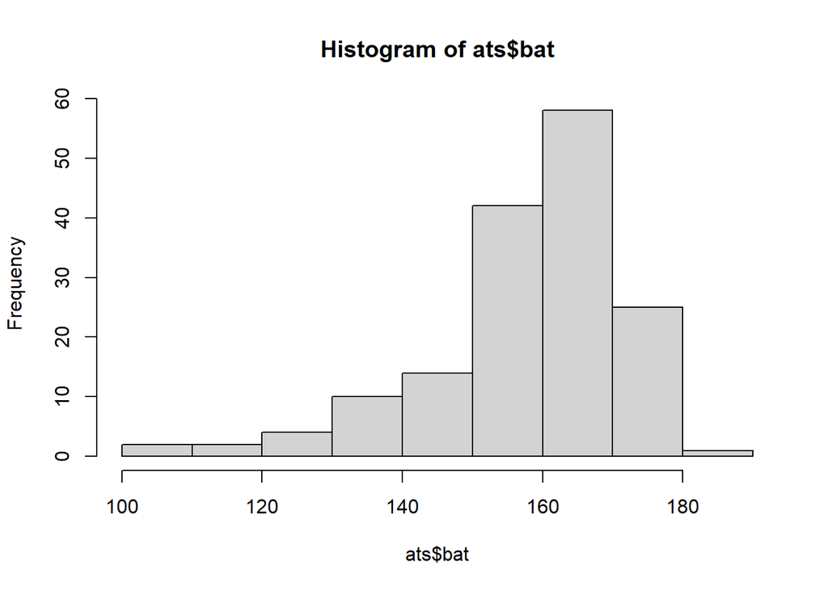

```r
# mean(ats$Average.Heart.Rate, na.rm = TRUE)
hist(ats$bat)
```

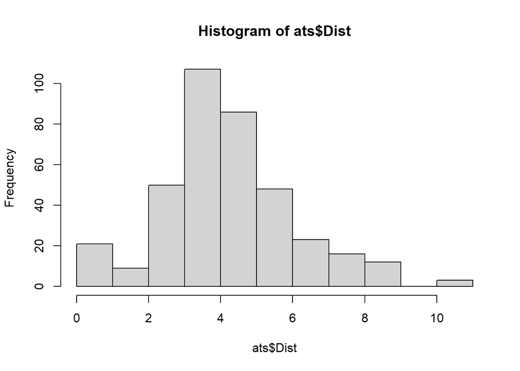

```r
hist(ats$Dist)
```

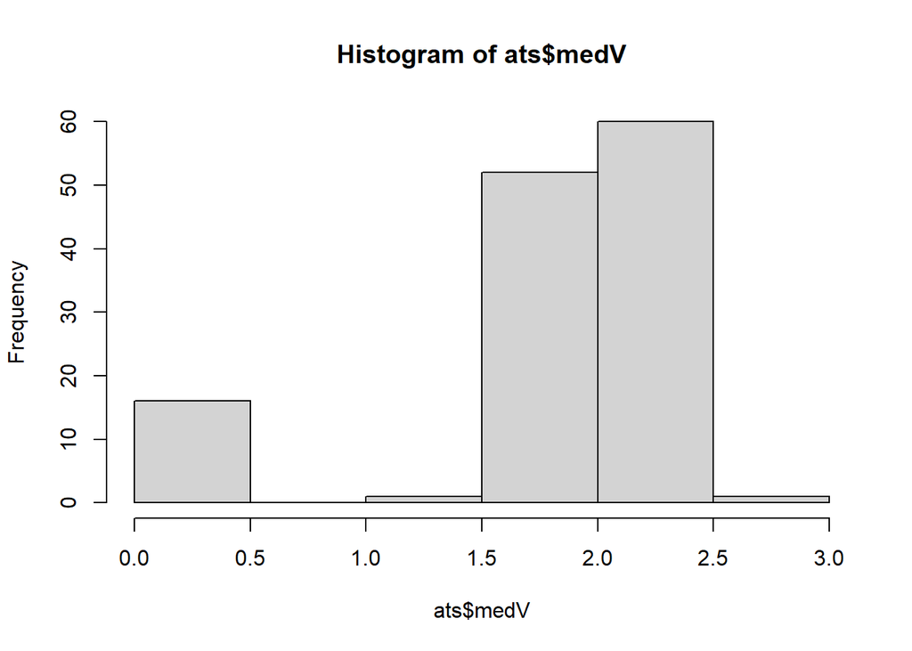

```r
hist(ats$medV)
```

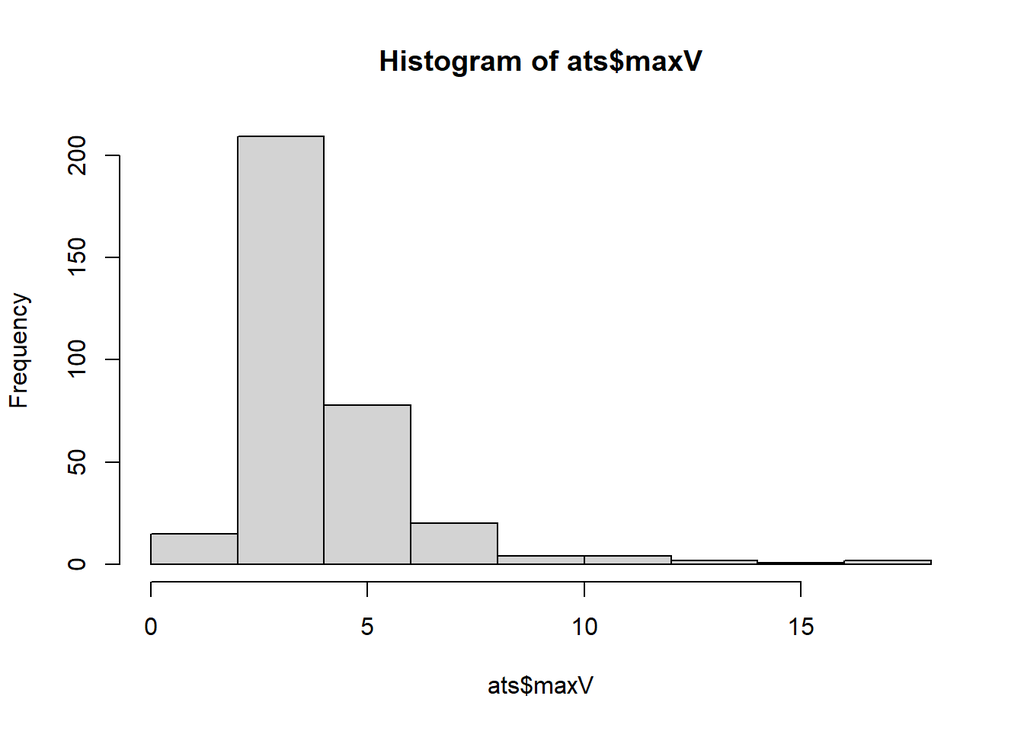

```r
hist(ats$maxV)
```

# Inferencial

Vamos testar a correlação entre as variáveis selecionadas.

```r
library(knitr)
kable(cor(ats, use = "complete.obs"))
```

|  | Tempo | Dist | maxV | medV | cad | bat |
| --- | --- | --- | --- | --- | --- | --- |
| Tempo | 1.0000000 | 0.9100328 | 0.2624436 | 0.4393750 | -0.1161119 | 0.1431784 |
| Dist | 0.9100328 | 1.0000000 | 0.5212482 | 0.7606124 | -0.2907557 | 0.1665599 |
| maxV | 0.2624436 | 0.5212482 | 1.0000000 | 0.7646499 | -0.5638311 | 0.0317469 |
| medV | 0.4393750 | 0.7606124 | 0.7646499 | 1.0000000 | -0.5599974 | 0.0637559 |
| cad | -0.1161119 | -0.2907557 | -0.5638311 | -0.5599974 | 1.0000000 | 0.5932792 |
| bat | 0.1431784 | 0.1665599 | 0.0317469 | 0.0637559 | 0.5932792 | 1.0000000 |

Testando a rede, usando um método N-1, pra poder controlar os efeitos temporais.

Se você quiser saber mais sobre redes, recomendo este artigo, que eu colaborei, ou o site dos caras que criaram o método:

Artigo: https://cdn.publisher.gn1.link/ggaging.com/pdf/en_v14n1a08.pdf

Site: http://psychosystems.org/

Infelizmente os dois estão em inglês, mas também existe uma capítulo muito bom sobre redes neste livro:

https://www.amazon.com.br/Psicometria-Claudio-Simon-Hutz/dp/8582712359/ref=sr_1_1?__mk_pt_BR=%C3%85M%C3%85%C5%BD%C3%95%C3%91&dchild=1&keywords=psicometria&qid=1611943762&sr=8-1

A biblioteca que vamos usar:

```r
library(graphicalVAR)
```

Nomes das variáveis, pra ficar mais fácil de lembrar:

```r
colnames(ats)
```

```
## [1] "Tempo" "Dist"  "maxV"  "medV"  "cad"   "bat"
```

Finalmente, a rede:

```r
summary(q)
```

[output not shown]

```
## === graphicalVAR results ===
## Number of nodes: 6
## Number of tuning parameters tested: 2500
## EBIC hyperparameter: 0.5
## Optimal EBIC: -206.3834
##
## Number of non-zero Partial Contemporaneous Correlations (PCC): 11
## PCC Sparsity: 0.2666667
## Number of PCC tuning parameters tested: 50
## PCC network stored in object$PCC
##
## Number of non-zero Partial Directed Correlations (PDC): 0
## PDC Sparsity: 1
## Number of PDC tuning parameters tested: 50
## PDC network stored in object$PDC
##
## Use plot(object) to plot the estimated networks.
```

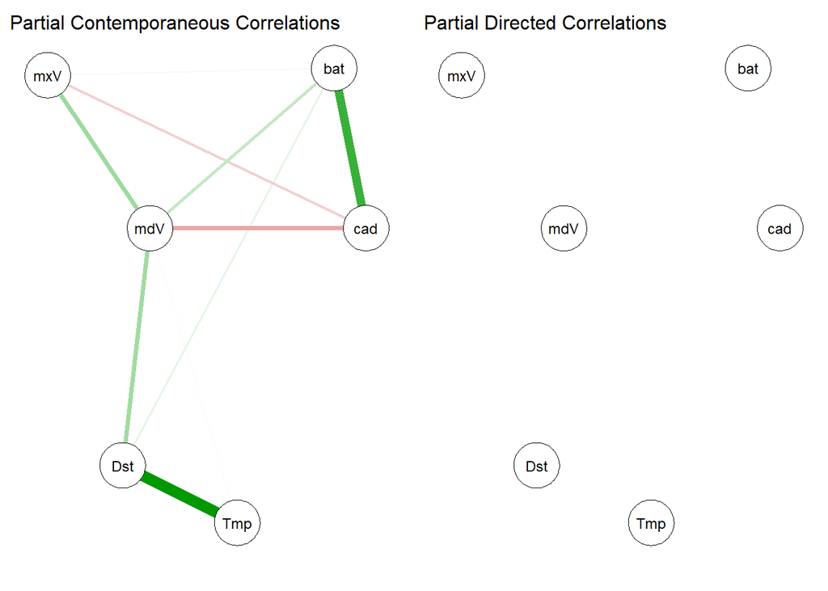

```r
plot(q)
```

```r
colnames(ats)
```

```
## [1] "Tempo" "Dist"  "maxV"  "medV"  "cad"   "bat"
```

# Resultados

De maneira mais interessante, o que encontramos foi: há uma relação negativa entre a cadência e a velocidade média. O que é ao contrário do esperando quando a gente olha os influenciadores de corrida. Isso pode ser uma influência de eu ter aumentado artificialmente a minha cadência. Além disso, aumentar a cadência está relacionado com aumento dos batimentos cardíacos médios, corrobora a hipótese de que o aumento aritficial da cadência pode ter sido um problema.